# Twitter Analysis Technical Report

vivek

July 27, 2017

Aim: We intend to search for last 5000 tweets , which have referred in one way or another to President Trump and will try to objectively find the sentiments keeping our biases out. Let us see what the sentiments are :

we will load the packages required for this analysis as these have already been installed on local machine.

```r
library(twitteR)
library(tm)
library(tidytext)
library(plyr)
```

```r
library(ggplot2)
library(stringi)
library(stringr)
library(wordcloud)
library(rebus)
library(dplyr)
```

we will now create a connection to twitter :

```r
source("C:\\Users\\vivek\\Documents\\dsla1\\twitterproject\\07.28.2017\\connectiontwitter.R")
```

```
## [1] "Using direct authentication"
```

Our Analysis will focus on the following :

```r
tw_user_potus<-getUser(user = "POTUS")
```

Following are few of the fields available to use:

```r
class(tw_user_potus)
```

```
## [1] "user"
## attr(,"package")
## [1] "twitteR"
```

```r
str(tw_user_potus)
```

```
## Reference class 'user' [package "twitteR"] with 18 fields
##  $ description      : chr "45th President of the United States of America, @realDonaldTrump. Tweets archived: https://t.co/eVVzoBb3Zr"
##  $ statusesCount    : num 953
##  $ followersCount   : num 19611518
##  $ favoritesCount   : num 58
##  $ friendsCount     : num 42
##  $ url              : chr "https://t.co/IxLjEB2zlE"
##  $ name             : chr "President Trump"
##  $ created          : POSIXct[1:1], format: "2017-01-19 22:54:28"
##  $ protected        : logi FALSE
##  $ verified         : logi TRUE
##  $ screenName       : chr "POTUS"
##  $ location         : chr "Washington, D.C."
##  $ lang             : chr "en"
##  $ id               : chr "822215679726100480"
##  $ lastStatus       :Reference class 'status' [package "twitteR"] with 17 fields
##   ..$ text         : chr "RT @realDonaldTrump: Departing for Long Island now. An area under siege from #MS13 gang members. We will not re"| __truncated__
##   ..$ favorited    : logi FALSE
##   ..$ favoriteCount: num 0
##   ..$ replyToSN    : chr(0)
##   ..$ created      : POSIXct[1:1], format: "2017-07-28 16:49:56"
##   ..$ truncated    : logi FALSE
##   ..$ replyToSID   : chr(0)
##   ..$ id           : chr "890977634972307456"
##   ..$ replyToUID   : chr(0)
##   ..$ statusSource : chr "<a href=\"http://twitter.com/download/iphone\" rel=\"nofollow\">Twitter for iPhone</a>"
##   ..$ screenName   : chr "Unknown"
##   ..$ retweetCount : num 11827
##   ..$ isRetweet    : logi TRUE
##   ..$ retweeted    : logi FALSE
##   ..$ longitude    : chr(0)
##   ..$ latitude     : chr(0)
##   ..$ urls         :'data.frame':    0 obs. of  4 variables:
##   .. ..$ url         : chr(0)
##   .. ..$ expanded_url: chr(0)
##   .. ..$ dispaly_url : chr(0)
##   .. ..$ indices     : num(0)
##   ..and 53 methods, of which 39 are  possibly relevant:
##   ..  getCreated, getFavoriteCount, getFavorited, getId, getIsRetweet,
##   ..  getLatitude, getLongitude, getReplyToSID, getReplyToSN,
##   ..  getReplyToUID, getRetweetCount, getRetweeted, getRetweeters,
##   ..  getRetweets, getScreenName, getStatusSource, getText, getTruncated,
##   ..  getUrls, initialize, setCreated, setFavoriteCount, setFavorited,
##   ..  setId, setIsRetweet, setLatitude, setLongitude, setReplyToSID,
##   ..  setReplyToSN, setReplyToUID, setRetweetCount, setRetweeted,
##   ..  setScreenName, setStatusSource, setText, setTruncated, setUrls,
##   ..  toDataFrame, toDataFrame#twitterObj
##  $ listedCount      : num 14703
##  $ followRequestSent: logi FALSE
##  $ profileImageUrl  : chr "http://pbs.twimg.com/profile_images/859982100904148992/hv5soju7_normal.jpg"
##  and 59 methods, of which 45 are  possibly relevant:
##    getCreated, getDescription, getFavorites, getFavoritesCount,
##    getFavouritesCount, getFollowerIDs, getFollowers, getFollowersCount,
##    getFollowRequestSent, getFriendIDs, getFriends, getFriendsCount, getId,
##    getLang, getLastStatus, getListedCount, getLocation, getName,
##    getProfileImageUrl, getProtected, getScreenName, getStatusesCount,
##    getUrl, getVerified, initialize, setCreated, setDescription,
##    setFavoritesCount, setFollowersCount, setFollowRequestSent,
##    setFriendsCount, setId, setLang, setLastStatus, setListedCount,
##    setLocation, setName, setProfileImageUrl, setProtected, setScreenName,
##    setStatusesCount, setUrl, setVerified, toDataFrame,
##    toDataFrame#twitterObj
```

Following us the little insight that we got from the user account information :

```r
tw_user_potus$lastStatus
```

```
## [1] "Unknown: RT @realDonaldTrump: Departing for Long Island now. An area under siege from #MS13 gang members. We will not rest until #MS13 is eradicated"
```

II . Twitter Analysis and word Cloud :

II-a. Collection of last 5000 tweets about “trump”

```r
tw_trump_search <- searchTwitter(searchString = "trump",n = 5000,lang = "en")
length(tw_trump_search)
```

```
## [1] 5000
```

```r
head(tw_trump_search)
```

```
## [[1]]
## [1] "vickiemwv: RT @pourmecoffee: Donald J. Trump, President of these United States, hereby unconditionally DEMANDS an IMMEDIATE vote on whatever. https://"
##
## [[2]]
## [1] "BobPreston2017: RT @RyanJensen2018: <ed> ½<ed>³Arizona District 1<ed> ½<ed>³\n\nElect Kevin Cavanaugh for Congress!\n\n✔️Pro Trump \n✔️Pro Border Wall\n✔️Pro #2A \n\nDONATE $5 NOW:\nht"
##
## [[3]]
## [1] "GonzaloWolfred: Trump to police: 'Please don't be too nice' to suspects - ABC News https://t.co/8JIgtd3XMZ"
##
## [[4]]
## [1] "kt_kymdoc: RT @anirvanghosh: @realDonaldTrump @skipper38 @Reince @Scaramucci @NewYorker It was difficult for Trump to work with @Reince, 'coz he doesn"
##
## [[5]]
## [1] "TomPandolfo: Trump is threatening to let sick people die if he doesn't get his way.\n\nIf you still support this man, shame on you https://t.co/EMduVH8St8"
##
## [[6]]
## [1] "AsanderDgr8: RT @BrianKarem: Heard from an old friend who worked hard to get Trump elected. He gave me cause for hope and renewed my faith with three wo"
```

```r
tw_POTUS_search <- searchTwitter(searchString = "@potus",n = 5000,lang = "en")
length(tw_POTUS_search)
```

```
## [1] 5000
```

```r
head(tw_POTUS_search)
```

```
## [[1]]
## [1] "JaimeAl80309976: @SenSchumer @POTUS that's the problem with politicians, you think that if you ACT like a Senator, ppl will believe that ur helping them"
##
## [[2]]
## [1] "RuChiOhu: RT @GainesvillePD: The @POTUS made remarks today that endorsed and condoned police brutality. \n\nGPD rejects these remarks and continues to"
##
## [[3]]
## [1] "LeftyGlenn: @ADVgrrls @Kcartwright77 @FoxNews @POTUS Like the ones who died in the back of that truck at Walmart?"
##
## [[4]]
## [1] "luauizzy: RT @GainesvillePD: The @POTUS made remarks today that endorsed and condoned police brutality. \n\nGPD rejects these remarks and continues to"
##
## [[5]]
## [1] "Victoriyup: RT @GPDBenTobias: I'm a cop. \n\nI do not agree with or condone @POTUS remarks today on police brutality. \n\nThose that applauded and cheered"
##
## [[6]]
## [1] "LifecoachNV16: RT @Big_Ahlers: @POTUS @SpeakerRyan @SenateMajLdr &amp; freeze their pay until they get er DONE! https://t.co/nl1easx1Ju"
```

```r
tail(tw_POTUS_search)
```

```
## [[1]]
## [1] "Mrsmaxdewinter: RT @BillKristol: \"On behalf of @POTUS.\" Ugh.\nMr. @VP, you are not Vice President of the Trump White House. You are Vice President of the Un"
##
## [[2]]
## [1] "windmillcharger: RT @SenSchumer: @POTUS .@POTUS ought to stop playing politics with people's lives &amp; #health care, start leading &amp; finally begin acting pres"
##
## [[3]]
## [1] "lemonbaryum: RT @MarkHertling: @JMSample @GPDBenTobias @POTUS Nope. Everyone should know better than to appease any bully. Bullies should be confronted"
##
## [[4]]
## [1] "Marc_Ullman: RT @GainesvillePD: The @POTUS made remarks today that endorsed and condoned police brutality. \n\nGPD rejects these remarks and continues to"
##
## [[5]]
## [1] "afterthebridge: RT @SenSchumer: If @POTUS refuses to make CSR payments, every expert agrees that premiums will go up &amp; #healthcare will be more expensive f"
##
## [[6]]
## [1] "Metascover: @Duckhuntinggrl @SFC_Rushing @Root4Change @GIJoeOPS @MycaLynn @MedicR56 @BethanyJuno @dawg_lb @MPlummer89 https://t.co/ZD7OmSPdKD"
```

III We will define few functions at this stage to clean up the teweets and will just focus on the text of the tweets

cleantweets function: Let us first strip the retweets(both manual and modified retweets are removed):

```r
tw_trump_search<-strip_retweets(tw_trump_search, strip_manual=TRUE, strip_mt=TRUE)
tw_POTUS_search<-strip_retweets(tw_POTUS_search, strip_manual=TRUE, strip_mt=TRUE)
```

let’s check the length of tweets lists now , it will give us an idea that how many real tweets are there after retweets are striped away

```r
length(tw_trump_search)
```

```
## [1] 1125
```

```r
length(tw_POTUS_search)
```

```
## [1] 1430
```

Let’s create dataframes of the tweets :

```r
tw_POTUS_search_df<-twListToDF(tw_POTUS_search)
head(tw_POTUS_search_df)
```

```
##                                                                                                                                           text
## 1      @SenSchumer @POTUS that's the problem with politicians, you think that if you ACT like a Senator, ppl will believe that ur helping them
## 2                                        @ADVgrrls @Kcartwright77 @FoxNews @POTUS Like the ones who died in the back of that truck at Walmart?
## 3 @ManualLabor1 @Magnoliagirl94 @VP @POTUS Time has come to prepare for the reality of truce. No previous President h https://t.co/aASbaez9kn
## 4                                                                                        @POTUS @RexTilllerson This... https://t.co/QZh7cDnraC
## 5                                                                              @quitthedems @sissineva @LouDobbs @POTUS Maybe you need some...
## 6 @Big_Ahlers @TRUMPMOMENTS1 @POTUS @SpeakerRyan @SenateMajLdr They've all become multi-millionaires off of our Treas https://t.co/17R50gyMxT
##   favorited favoriteCount    replyToSN             created truncated
## 1     FALSE             0   SenSchumer 2017-07-29 20:56:38     FALSE
## 2     FALSE             0     ADVgrrls 2017-07-29 20:56:38     FALSE
## 3     FALSE             0 ManualLabor1 2017-07-29 20:56:35      TRUE
## 4     FALSE             0        POTUS 2017-07-29 20:56:35     FALSE
## 5     FALSE             0  quitthedems 2017-07-29 20:56:34     FALSE
## 6     FALSE             1   Big_Ahlers 2017-07-29 20:56:33      TRUE
##           replyToSID                 id         replyToUID
```

[output cut: 20 more lines]

```r
str(tw_POTUS_search_df)
```

```
## 'data.frame':    1430 obs. of  16 variables:
##  $ text         : chr  "@SenSchumer @POTUS that's the problem with politicians, you think that if you ACT like a Senator, ppl will beli"| __truncated__ "@ADVgrrls @Kcartwright77 @FoxNews @POTUS Like the ones who died in the back of that truck at Walmart?" "@ManualLabor1 @Magnoliagirl94 @VP @POTUS…
##  $ favorited    : logi  FALSE FALSE FALSE FALSE FALSE FALSE ...
##  $ favoriteCount: num  0 0 0 0 0 1 0 0 0 0 ...
##  $ replyToSN    : chr  "SenSchumer" "ADVgrrls" "ManualLabor1" "POTUS" ...
##  $ created      : POSIXct, format: "2017-07-29 20:56:38" "2017-07-29 20:56:38" ...
##  $ truncated    : logi  FALSE FALSE TRUE FALSE FALSE TRUE ...
##  $ replyToSID   : chr  "891359143923265537" "891101725309972481" "891312432299356160" NA ...
##  $ id           : chr  "891402109324640256" "891402107521290242" "891402096041353216" "891402093692571648" ...
##  $ replyToUID   : chr  "17494010" "305387875" "850503408507387905" "822215679726100480" ...
##  $ statusSource : chr  "<a href=\"http://twitter.com/download/iphone\" rel=\"nofollow\">Twitter for iPhone</a>" "<a href=\"http://twitter.com/#!/download/ipad\" rel=\"nofollow\">Twitter for iPad</a>" "<a href=\"http://twitter.com/download/android\" rel=\"nofollow\">Twitter for Android</a>" "<a hr…
##  $ screenName   : chr  "JaimeAl80309976" "LeftyGlenn" "Johnath66175647" "traybishop" ...
##  $ retweetCount : num  0 0 0 0 0 0 0 0 0 0 ...
##  $ isRetweet    : logi  FALSE FALSE FALSE FALSE FALSE FALSE ...
##  $ retweeted    : logi  FALSE FALSE FALSE FALSE FALSE FALSE ...
##  $ longitude    : logi  NA NA NA NA NA NA ...
##  $ latitude     : logi  NA NA NA NA NA NA ...
```

```r
tw_trump_search_df<-twListToDF(tw_trump_search)
head(tw_trump_search_df)
```

```
##                                                                                                                                             text
## 1                                                     Trump to police: 'Please don't be too nice' to suspects - ABC News https://t.co/8JIgtd3XMZ
## 2 Trump is threatening to let sick people die if he doesn't get his way.\n\nIf you still support this man, shame on you https://t.co/EMduVH8St8
## 3    I interviewed with Newsweek's @maxkutner this week to discuss the upcoming solar eclipse and its potential effects https://t.co/BQFzQ4tVQh
## 4   @LindseyGrahamSCIt is time to end this imposter to the throne.Get rid of Trump.  Mr Graham,you can do better!The Boy Scouts?The Mooch?Please
## 5                         The Wall Street Journal: Trump threatens to end health care bailouts for lawmakers, insurers https://t.co/Ej2e4eU97x
## 6   @realDonaldTrump Each day that goes by I regret my Trump vote just a little more. I thought you would make deals bu https://t.co/DB0JBQhTji
##   favorited favoriteCount       replyToSN             created truncated
## 1     FALSE             0            <NA> 2017-07-29 20:55:29     FALSE
## 2     FALSE             0            <NA> 2017-07-29 20:55:29      TRUE
## 3     FALSE             0            <NA> 2017-07-29 20:55:28      TRUE
## 4     FALSE             0            <NA> 2017-07-29 20:55:28     FALSE
## 5     FALSE             0            <NA> 2017-07-29 20:55:28     FALSE
## 6     FALSE             0 realDonaldTrump 2017-07-29 20:55:28      TRUE
##           replyToSID                 id replyToUID
```

[output cut: 20 more lines]

```r
str(tw_trump_search_df)
```

```
## 'data.frame':    1125 obs. of  16 variables:
##  $ text         : chr  "Trump to police: 'Please don't be too nice' to suspects - ABC News https://t.co/8JIgtd3XMZ" "Trump is threatening to let sick people die if he doesn't get his way.\n\nIf you still support this man, shame "| __truncated__ "I interviewed with Newsweek's @maxkutner this week …
##  $ favorited    : logi  FALSE FALSE FALSE FALSE FALSE FALSE ...
##  $ favoriteCount: num  0 0 0 0 0 0 0 0 0 0 ...
##  $ replyToSN    : chr  NA NA NA NA ...
##  $ created      : POSIXct, format: "2017-07-29 20:55:29" "2017-07-29 20:55:29" ...
##  $ truncated    : logi  FALSE TRUE TRUE FALSE FALSE TRUE ...
##  $ replyToSID   : chr  NA NA NA NA ...
##  $ id           : chr  "891401817187389440" "891401817153617920" "891401815354245120" "891401814666620928" ...
##  $ replyToUID   : chr  NA NA NA NA ...
##  $ statusSource : chr  "<a href=\"https://ifttt.com\" rel=\"nofollow\">IFTTT</a>" "<a href=\"http://twitter.com\" rel=\"nofollow\">Twitter Web Client</a>" "<a href=\"http://twitter.com\" rel=\"nofollow\">Twitter Web Client</a>" "<a href=\"http://twitter.com\" rel=\"nofollow\">Twitter Web Client</…
##  $ screenName   : chr  "GonzaloWolfred" "TomPandolfo" "WadeCavesAstro" "johnwwc" ...
##  $ retweetCount : num  0 0 0 0 0 0 0 0 0 0 ...
##  $ isRetweet    : logi  FALSE FALSE FALSE FALSE FALSE FALSE ...
##  $ retweeted    : logi  FALSE FALSE FALSE FALSE FALSE FALSE ...
##  $ longitude    : chr  NA NA NA NA ...
##  $ latitude     : chr  NA NA NA NA ...
```

Following Function will remove links,retweet entries,hashtags,@people,punctuations, digits and spaces

```r
cleantweets<- function(tweet){
  # Clean the tweet for sentiment analysis
  # remove html links, which are not required for sentiment analysis
  tweet = gsub("(f|ht)(tp)(s?)(://)(.*)[.|/](.*)", " ", tweet)
  # First we will remove retweet entities from  the stored tweets (text)
  tweet = gsub("(RT|via)((?:\\b\\W*@\\w+)+)", " ", tweet)
  # Then remove all "#Hashtag"
  tweet = gsub("#\\w+", " ", tweet)
  # Then remove all "@people"
  tweet = gsub("@\\w+", " ", tweet)
  # Then remove all the punctuation
  tweet = gsub("[[:punct:]]", " ", tweet)
  # Then remove numbers, we need only text for analytics
  tweet = gsub("[[:digit:]]", " ", tweet)
  # finally, we remove unnecessary spaces (white spaces, tabs etc)
  tweet = gsub("[ \t]{2,}", " ", tweet)
  tweet = gsub("^\\s+|\\s+$", "", tweet)
}
```

In the next function we will use above function and remove na’s too.

```r
clean_tweets_and_na<- function(Tweets) {
  TweetsCleaned = sapply(Tweets, cleantweets)
  # Remove the "NA" tweets from this tweet list
  TweetsCleaned = TweetsCleaned[!is.na(TweetsCleaned)]
  names(TweetsCleaned) = NULL
  # Remove the repetitive tweets from this tweet list
  TweetsCleaned = unique(TweetsCleaned)
  TweetsCleaned }
```

let us first get text field from the tweets collected :

```r
tw_trump_search_txt<-sapply(tw_trump_search,function(x) x$getText())
tw_POTUS_search_txt<-sapply(tw_POTUS_search,function(x) x$getText())
```

To remove the icons/emoji’s etc :

```r
tw_trump_search_txt<-sapply(tw_trump_search_txt,function(x) iconv(x ,to="UTF-8",sub = "" ))
tw_POTUS_search_txt<-sapply(tw_POTUS_search_txt,function(x) iconv(x ,to="UTF-8",sub = "" ))
```

let’s apply the created function to clean text:

```r
tw_trump_search_txt_cln1<-clean_tweets_and_na(tw_trump_search_txt)
tw_POTUS_search_txt_cln1<-clean_tweets_and_na(tw_POTUS_search_txt)
```

Let’s create the corpus now:

```r
tw_trump_search_corpus<-Corpus(VectorSource(tw_trump_search_txt_cln1))
tw_POTUS_search_corpus<-Corpus(VectorSource(tw_POTUS_search_txt_cln1))
```

Let’s first get the stopwords before we start cleaning the corpus:

```r
tw_stopwords <-stopwords("english")
```

Let’s define a function to create a cleaner corpus with lowercase, removed punctuations, removed numbers and removed stopwords:

```r
cleancorpus<-function(incorpus){
  incorpus <- tm_map(incorpus, tolower)
  incorpus <- tm_map(incorpus, removePunctuation)
  incorpus <- tm_map(incorpus, removeNumbers)
  incorpus <- tm_map(incorpus, removeWords, tw_stopwords)
}
```

Clean the corpus using the function:

```r
tw_trump_search_corpus<-cleancorpus(tw_trump_search_corpus)
tw_POTUS_search_corpus<-cleancorpus(tw_POTUS_search_corpus)
inspect(tw_trump_search_corpus)
```

```
## <<SimpleCorpus>>
## Metadata:  corpus specific: 1, document level (indexed): 0
## Content:  documents: 1063
##
##    [1] trump  police please don t   nice  suspects abc news
##    [2] trump  threatening  let sick people die   doesn t get  way \n\n  still support  man shame  youâ
##    [3]  interviewed  newsweek s  week  discuss  upcoming solar eclipse   potential effectsâ
##    [4]  time  end  imposter   throne get rid  trump mr graham  can  better  boy scouts  mooch please
##    [5]  wall street journal trump threatens  end health care âbailoutsâ  lawmakers insurers
##    [6]  day  goes   regret  trump vote just  little   thought   make deals buâ
##    [7] trump s pals putin   gang  thieves
##    [8] get prepared  d melt addressed d last thing  hand
##    [9]
##   [10]  can t stand trump  winflop  right
##   [11]    putin s interference   voting process   aided   trump regime compare  dws  firing someone
```

[output cut: 1052 more lines]

```r
inspect(tw_POTUS_search_corpus)
```

```
## <<SimpleCorpus>>
## Metadata:  corpus specific: 1, document level (indexed): 0
## Content:  documents: 1311
##
##    [1]  s  problem  politicians  think    act like  senator ppl will believe  ur helping
##    [2] like  ones  died   back   truck  walmart
##    [3] time  come  prepare   reality  truce  previous president hâ
##    [4]
##    [5] maybe  need
##    [6]  ve  become multi millionaires    treasâ
##    [7] perhaps  obamacare fine goes   senate s personal bank accounts
##    [8]  still  heavy hand  government still wants control   personnel social health  religious choices
##    [9]  bad enough people didn t listen  romney   moronic maniacal defect  humanity
##   [10]
##   [11]  course  didn t hear  peep    huge double standard obama   disaster
```

[output cut: 1300 more lines]

# Create a Document Term Matrix

Let’s create the Document Term Matrices now for both the corpuses:

```r
tw_trump_DTM<-DocumentTermMatrix(tw_trump_search_corpus,list(termFreq=1))
inspect(tw_trump_DTM)
```

```
## <<DocumentTermMatrix (documents: 1063, terms: 3264)>>
## Non-/sparse entries: 8834/3460798
## Sparsity           : 100%
## Maximal term length: 17
## Weighting          : term frequency (tf)
## Sample             :
##       Terms
## Docs   amp can donald get just like people president trump will
##   1009   0   0      0   0    0    0      0         0     2    0
##   137    1   0      1   0    0    0      0         0     1    0
##   224    0   0      0   0    0    1      0         0     1    0
##   302    0   0      0   0    0    0      0         0     1    0
##   47     0   1      0   0    0    0      0         0     3    0
##   76     0   0      0   0    0    0      0         0     2    0
##   814    3   0      1   0    0    0      0         0     1    0
##   84     0   0      0   0    0    0      0         0     1    0
##   886    0   0      0   0    0    0      0         0     1    0
##   975    1   0      0   0    0    0      0         0     1    0
```

```r
saveRDS(tw_trump_DTM,"./tw_trump_DTM")
tw_POTUS_DTM<-DocumentTermMatrix(tw_POTUS_search_corpus,list(termFreq=1))
inspect(tw_POTUS_DTM)
```

```
## <<DocumentTermMatrix (documents: 1311, terms: 3362)>>
## Non-/sparse entries: 8255/4399327
## Sparsity           : 100%
## Maximal term length: 17
## Weighting          : term frequency (tf)
## Sample             :
##       Terms
## Docs   amp can don get like people please thank trump will
##   1020   1   0   0   0    0      0      0     0     0    0
##   260    1   0   0   0    0      0      0     0     0    0
##   289    1   0   0   0    0      2      0     0     0    0
##   335    1   0   0   0    0      0      0     0     0    0
##   787    1   0   0   0    0      0      0     0     0    0
##   79     2   0   0   0    0      0      0     0     0    0
##   821    0   0   0   0    1      0      0     0     0    0
##   843    0   0   0   0    0      0      0     0     0    0
##   889    1   0   0   0    0      0      0     0     0    2
##   931    0   0   0   0    0      0      0     0     0    0
```

```r
saveRDS(tw_POTUS_DTM,"./tw_POTUS_DTM")
```

Let’s check the frequent terms for “trump” and “POTUS”

```r
tw_trump_freqterms<-findFreqTerms(tw_trump_DTM,lowfreq = 10)
tw_POTUS_freqterms<-findFreqTerms(tw_POTUS_DTM,lowfreq = 10)
```

let’s examine the frequent terms:

```r
tw_trump_freqterms
```

```
##   [1] "don"            "news"           "please"         "police"
##   [5] "trump"          "doesn"          "get"            "let"
##   [9] "man"            "people"         "sick"           "still"
##  [13] "support"        "way"            "week"           "better"
##  [17] "boy"            "can"            "end"            "mooch"
##  [21] "time"           "care"           "health"         "lawmakers"
##  [25] "threatens"      "day"            "just"           "make"
##  [29] "vote"           "thing"          "right"          "someone"
##  [33] "isn"            "president"      "american"       "tweets"
##  [37] "twitter"        "will"           "voted"          "trumpÃ"
##  [41] "done"           "gop"            "administration" "good"
##  [45] "like"           "obama"          "donald"         "transgender"
##  [49] "obamacare"      "payments"       "repeal"         "military"
##  [53] "house"          "said"           "white"          "won"
##  [57] "americans"      "john"           "amp"            "give"
```

[output cut: 17 more lines]

```r
tw_POTUS_freqterms
```

```
##   [1] "like"        "think"       "will"        "back"        "come"
##   [6] "president"   "time"        "maybe"       "need"        "obamacare"
##  [11] "senate"      "government"  "health"      "still"       "bad"
##  [16] "didn"        "people"      "obama"       "service"     "anything"
##  [21] "americans"   "agree"       "also"        "american"    "amp"
##  [26] "mccain"      "republicans" "congress"    "don"         "yet"
##  [31] "thÃ"         "let"         "see"         "another"     "right"
##  [36] "vote"        "get"         "even"        "trump"       "twitter"
##  [41] "just"        "money"       "dems"        "today"       "can"
##  [46] "keep"        "make"        "must"        "new"         "god"
##  [51] "less"        "care"        "explain"     "way"         "good"
##  [56] "call"        "help"        "one"         "please"      "put"
##  [61] "sir"         "law"         "potus"       "pay"         "job"
##  [66] "know"        "âÃ"        "want"        "best"        "really"
##  [71] "work"        "actually"    "idea"        "never"       "senators"
##  [76] "needs"       "thank"       "love"        "healthcare"  "now"
##  [81] "police"      "party"       "bill"        "ass"         "something"
##  [86] "going"       "much"        "russia"      "point"       "say"
##  [91] "great"       "news"        "everyone"    "nothing"     "thanks"
##  [96] "use"         "doesn"       "exemption"   "tweet"       "yes"
## [101] "swamp"       "done"        "said"        "called"      "insurance"
## [106] "years"       "rules"       "exactly"     "take"        "mean"
## [111] "nice"        "america"     "real"        "ever"        "stop"
## [116] "office"      "hate"        "made"        "sad"         "thing"
## [121] "country"     "aca"         "working"     "votes"       "man"
## [126] "day"         "pass"        "well"        "give"        "wrong"
## [131] "every"       "hope"        "hard"        "hey"         "repeal"
## [136] "move"        "ÂÃ"
```

finding the term frequencies:

```r
tw_trump_termfreq<-colSums(as.matrix(tw_trump_DTM))
tw_trump_termfreq_df<-data.frame(term = names(tw_trump_termfreq),freq=tw_trump_termfreq)
tw_POTUS_termfreq<-colSums(as.matrix(tw_POTUS_DTM))
tw_POTUS_termfreq_df<-data.frame(term = names(tw_POTUS_termfreq),freq=tw_POTUS_termfreq)
```

we can examine the frequent terms and their frequency for “trump” keyword:

```r
tw_trump_termfreq_df
```

```
##                                term freq
## abc                             abc    2
## don                             don   33
## news                           news   14
## nice                           nice    6
## please                       please   11
## police                       police   33
## suspects                   suspects    3
## trump                         trump  853
## die                             die    3
## doesn                         doesn   17
## get                             get   40
## let                             let   16
## man                             man   10
## people                       people   38
## shame                         shame    2
## sick                           sick   11
## still                         still   25
## support                     support   11
## threatening             threatening    5
## way                             way   27
## youÃ                           youÃ    3
## discuss                     discuss    1
## eclipse                     eclipse    1
## effectsÃ                   effectsÃ    1
## interviewed             interviewed    2
## newsweek                   newsweek    1
## potential                 potential    2
## solar                         solar    1
## upcoming                   upcoming    1
## week                           week   11
## better                       better   14
## boy                             boy   14
## can                             can   67
## end                             end   32
## graham                       graham    3
## imposter                   imposter    4
## mooch                         mooch   11
## rid                             rid    9
## scouts                       scouts    8
```

[output cut: 3210 more lines]

```
## emergency                 emergency    1
## indicating               indicating    1
## bipartisan               bipartisan    1
## fixed                         fixed    1
## improved                   improved    1
## potusÃ                       potusÃ    1
## manhattan                 manhattan    1
## sketch                       sketch    1
## skyline                     skyline    1
## sold                           sold    1
## bizeran                     bizeran    1
## eliminated               eliminated    1
## instance                   instance    1
## employer                   employer    1
## taÃ                             taÃ    1
```

```r
tw_POTUS_termfreq_df
```

```
##                                term freq
## act                             act    6
## believe                     believe    8
## helping                     helping    2
## like                           like   62
## politicians             politicians    4
## ppl                             ppl    8
## problem                     problem    7
## senator                     senator    6
## think                         think   22
## will                           will   67
## back                           back   22
## died                           died    1
## ones                           ones    5
## truck                         truck    1
## walmart                     walmart    1
## come                           come   14
## prepare                     prepare    1
## president                 president   33
## previous                   previous    2
## reality                     reality    5
## time                           time   25
## truce                         truce    1
## maybe                         maybe   13
## need                           need   26
## become                       become    6
## millionaires           millionaires    1
## multi                         multi    2
## treasÃ                       treasÃ    1
## accounts                   accounts    1
## bank                           bank    1
## fine                           fine    4
## goes                           goes    3
## obamacare                 obamacare   23
## perhaps                     perhaps    2
## personal                   personal    3
## senate                       senate   13
## choices                     choices    1
## control                     control    7
## government               government   10
```

[output cut: 3308 more lines]

```
## preforming               preforming    1
## education                 education    1
## bulgy                         bulgy    1
## covered                     covered    1
## ratings                     ratings    1
## evaluation               evaluation    1
## heyer                         heyer    1
## acts                           acts    1
## charitable               charitable    1
## googling                   googling    1
## prior                         prior    1
## vacation                   vacation    1
## demands                     demands    1
## enforce                     enforce    1
## include                     include    1
```

At this stage we are interested in looking into Word Cloud for the keyword “trump” :

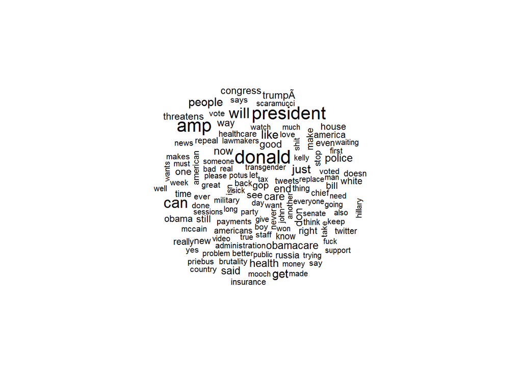

```r
wordcloud(words = tw_trump_freqterms,
          freq = tw_trump_termfreq_df[tw_trump_termfreq_df$term %in% tw_trump_freqterms,2],
            colors = T,random.color = T,scale = c(10,0.5))
```

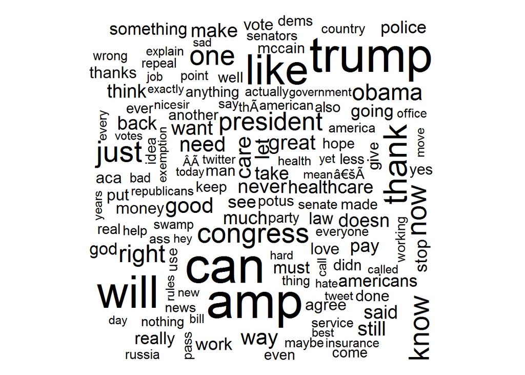

```r
wordcloud(words = tw_POTUS_freqterms,
          freq = tw_POTUS_termfreq_df[tw_POTUS_termfreq_df$term %in% tw_POTUS_freqterms,2],
          colors = T,random.color = T)
```

We want to look into the comparison cloud of both the groups i.e. are they using different terms in their communication :

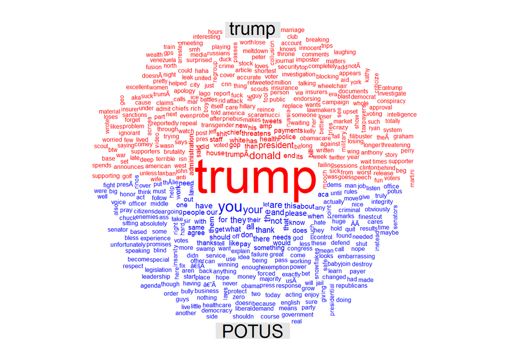

```r
tweets_trump<-paste(tw_trump_search_txt_cln1, collapse=" ")
tweets_POTUS<-paste(tw_POTUS_search_txt_cln1, collapse=" ")
total<-c(tweets_trump,tweets_POTUS)
total_corpus<-Corpus(x = VectorSource(total))
total_tdm<-TermDocumentMatrix(total_corpus)
total_tdm_matrix<-as.matrix(total_tdm)
colnames(total_tdm_matrix)<-c("trump","POTUS")
comparison.cloud(total_tdm_matrix,random.order = FALSE,colors = c("red","blue"),title.size = 1.5,max.words = 500)
```

It is good to look at the commonality cloud to find out the terms that common to both the groups :

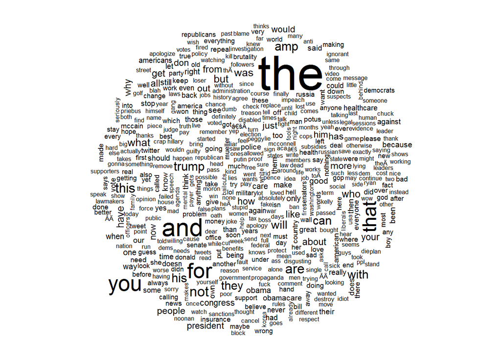

```r
commonality.cloud(total_tdm_matrix,max.words = 500)
```

## Sentiment Analysis :

We will now focus on the sentimental analysis of the data collected from the twitter feeds using keywword " trump" and from twitter handle “POTUS”

1. we will load the libraries required first:

```r
library(twitteR)
library(stringr)
library(ggplot2)
```

2. We will create the scoring function first that will be used to score the sentiment of the tweet. It is based on splitting the tweet in words and then assigning polarity to the words. final polarity of the tweet is the sum of polarities of the words in tweet

```r
sentiment_score = function(sentences, pos.words, neg.words, .progress='none')
{  scores = laply(sentences,
                 function(sentence, pos.words, neg.words)
                 {
                   # remove punctuation
                   sentence = gsub("[[:punct:]]", "", sentence)
                   # remove control characters
                   sentence = gsub("[[:cntrl:]]", "", sentence)
                   # remove digits?
                   sentence = gsub('\\d+', '', sentence)

                   # define error handling function when trying tolower
                   tryTolower = function(x)
                   {
                     # create missing value
                     y = NA
                     # tryCatch error
                     try_error = tryCatch(tolower(x), error=function(e) e)
                     # if not an error
                     if (!inherits(try_error, "error"))
                       y = tolower(x)
                     # result
                     return(y)
                   }
                   # use tryTolower with sapply
                   sentence = sapply(sentence, tryTolower)

                   # split sentence into words with str_split (stringr package)
                   word.list = str_split(sentence, "\\s+")
                   words = unlist(word.list)

                   # compare words to the dictionaries of positive & negative terms
                   pos.matches = match(words, pos.words)
                   neg.matches = match(words, neg.words)

                   # get the position of the matched term or NA
                   # we just want a TRUE/FALSE
                   pos.matches = !is.na(pos.matches)
                   neg.matches = !is.na(neg.matches)

                   # final score
                   score = sum(pos.matches) - sum(neg.matches)
                   return(score)
                 }, pos.words, neg.words, .progress=.progress )

  # data frame with scores for each sentence
  scores.df = data.frame(text=sentences, score=scores)
  return(scores.df)
}
```

3. We will import the positive words as well as negative words against which the polarity of tweets will be decided. these lists are present in the working directory of the project , so will be imported without giving the full path to files:

```r
pos = readLines("positive_words.txt")
neg = readLines("negative_words.txt")
```

4. we already have tweets from " trump" and " @POTUS" and cleaned also by running the functions in the first part( exploration of data) of the project. We will analyse the same data to futher extend the understanding of data:

```r
no_of_tweets<-c(length(tw_trump_search_txt_cln1), length(tw_POTUS_search_txt_cln1))
names(no_of_tweets)<-c("trump","POTUS")
no_of_tweets
```

```
## trump POTUS
##  1063  1311
```

5. we will join the texts now to make a single collection :

```r
#5 join texts
trump_POTUS_alltweets = c(tw_trump_search_txt_cln1,tw_POTUS_search_txt_cln1)
length(trump_POTUS_alltweets)
```

```
## [1] 2374
```

6. We will now apply the fuction created earlier namely sentiment_score , will check the resultant data for structure and no. of rows

```r
trump_POTUS_alltweets_score<-sentiment_score(trump_POTUS_alltweets,pos,neg,.progress = 'text')
head(trump_POTUS_alltweets_score)
```

```
##                                                                                                                      text
## 1                                                           Trump to police Please don t be too nice to suspects ABC News
## 2  Trump is threatening to let sick people die if he doesn t get his way \n\nIf you still support this man shame on youâ
## 3               I interviewed with Newsweek s this week to discuss the upcoming solar eclipse and its potential effectsâ
## 4 is time to end this imposter to the throne Get rid of Trump Mr Graham you can do better The Boy Scouts The Mooch Please
## 5                        The Wall Street Journal Trump threatens to end health care âbailoutsâ for lawmakers insurers
## 6                     Each day that goes by I regret my Trump vote just a little more I thought you would make deals buâ
##   score
## 1     2
## 2    -2
## 3     0
## 4     2
## 5     1
## 6     0
```

```r
nrow(trump_POTUS_alltweets_score)
```

```
## [1] 2374
```

7. We will add another variable to the data frame now which will identify the source of tweet i.e. either " trump" or “POTUS”

```r
trump_POTUS_alltweets_score$source = factor(rep(c("trump", "POTUS"), no_of_tweets))
head(trump_POTUS_alltweets_score)
```

```
##                                                                                                                      text
## 1                                                           Trump to police Please don t be too nice to suspects ABC News
## 2  Trump is threatening to let sick people die if he doesn t get his way \n\nIf you still support this man shame on youâ
## 3               I interviewed with Newsweek s this week to discuss the upcoming solar eclipse and its potential effectsâ
## 4 is time to end this imposter to the throne Get rid of Trump Mr Graham you can do better The Boy Scouts The Mooch Please
## 5                        The Wall Street Journal Trump threatens to end health care âbailoutsâ for lawmakers insurers
## 6                     Each day that goes by I regret my Trump vote just a little more I thought you would make deals buâ
##   score source
## 1     2  trump
## 2    -2  trump
## 3     0  trump
## 4     2  trump
## 5     1  trump
## 6     0  trump
```

```r
tail(trump_POTUS_alltweets_score)
```

```
##                                                                                                                          text
## 2369                                                            Thanks Mr Heyer for your honest evaluation of transgender ban
## 2370                                                                      Try Googling his charitable acts prior to being Iâ
## 2371                                                                              Ur both wrong Beck called u out trump Pussy
## 2372                                                                    Well guess should give up and vacation Heck I wouldâ
## 2373                                                                                                     You made it too easy
## 2374 Stop acting like a dumbass and enforce the Law which currently does include the ACA you position as President demands it
##      score source
## 2369     1  POTUS
## 2370     1  POTUS
## 2371     0  POTUS
## 2372     0  POTUS
## 2373     1  POTUS
## 2374     1  POTUS
```

```r
table(trump_POTUS_alltweets_score$source,trump_POTUS_alltweets_score$score)
```

```
##
##          -6  -5  -4  -3  -2  -1   0   1   2   3   4   5
##   POTUS   0   3   7  29  91 274 566 250  67  15   8   1
##   trump   1   1   3  12  54 142 305 348 151  38   6   2
```

```r
trump_POTUS_alltweets_score$very_positive = as.numeric(trump_POTUS_alltweets_score$score >= 4)
trump_POTUS_alltweets_score$positive = as.numeric(trump_POTUS_alltweets_score$score >= 0 & trump_POTUS_alltweets_score$score < 4)
trump_POTUS_alltweets_score$neutral = as.numeric(trump_POTUS_alltweets_score$score ==0)
trump_POTUS_alltweets_score$negative = as.numeric(trump_POTUS_alltweets_score$score < 0 & trump_POTUS_alltweets_score$score > -4)
trump_POTUS_alltweets_score$very_negative = as.numeric(trump_POTUS_alltweets_score$score <= -4)
head(trump_POTUS_alltweets_score)
```

```
##                                                                                                                      text
## 1                                                           Trump to police Please don t be too nice to suspects ABC News
## 2  Trump is threatening to let sick people die if he doesn t get his way \n\nIf you still support this man shame on youâ
## 3               I interviewed with Newsweek s this week to discuss the upcoming solar eclipse and its potential effectsâ
## 4 is time to end this imposter to the throne Get rid of Trump Mr Graham you can do better The Boy Scouts The Mooch Please
## 5                        The Wall Street Journal Trump threatens to end health care âbailoutsâ for lawmakers insurers
## 6                     Each day that goes by I regret my Trump vote just a little more I thought you would make deals buâ
##   score source very_positive positive neutral negative very_negative
## 1     2  trump             0        1       0        0             0
## 2    -2  trump             0        0       0        1             0
## 3     0  trump             0        1       1        0             0
## 4     2  trump             0        1       0        0             0
## 5     1  trump             0        1       0        0             0
## 6     0  trump             0        1       1        0             0
```

8. Now we have categorized the tweets in very positives ,positive,neutral,negative and very negative, we will calculate the global positivity score to figure out the overall positivity:

```r
trump_POTUS_alltweets_emotion_verypos<-sum(trump_POTUS_alltweets_score$very_positive)->s1
trump_POTUS_alltweets_emotion_pos<-sum(trump_POTUS_alltweets_score$positive)->s2
trump_POTUS_alltweets_emotion_neutral<-sum(trump_POTUS_alltweets_score$neutral)->s3
trump_POTUS_alltweets_emotion_neg<-sum(trump_POTUS_alltweets_score$negative)->s4
trump_POTUS_alltweets_emotion_veryneg<-sum(trump_POTUS_alltweets_score$very_negative)->s5
global_pos_score<-(s1+s2)/(s1+s2+s3+s4+s5)
global_pos_score
```

```
## [1] 0.5414484
```

```r
str(trump_POTUS_alltweets_score)
```

```
## 'data.frame':    2374 obs. of  8 variables:
##  $ text         : Factor w/ 2353 levels "","","a bit hack who said is her best boss Her marriage barely lasted years Another loser judging",..: 1944 1878 714 901 1680 394 1907 491 1 675 ...
##  $ score        : int  2 -2 0 2 1 0 1 0 0 2 ...
##  $ source       : Factor w/ 2 levels "POTUS","trump": 2 2 2 2 2 2 2 2 2 2 ...
##  $ very_positive: num  0 0 0 0 0 0 0 0 0 0 ...
##  $ positive     : num  1 0 1 1 1 1 1 1 1 1 ...
##  $ neutral      : num  0 0 1 0 0 1 0 1 1 0 ...
##  $ negative     : num  0 1 0 0 0 0 0 0 0 0 ...
##  $ very_negative: num  0 0 0 0 0 0 0 0 0 0 ...
```

9. we will now check the overall spread of positivity or negativity amoung these two sources and compare their polarity sourcewise :

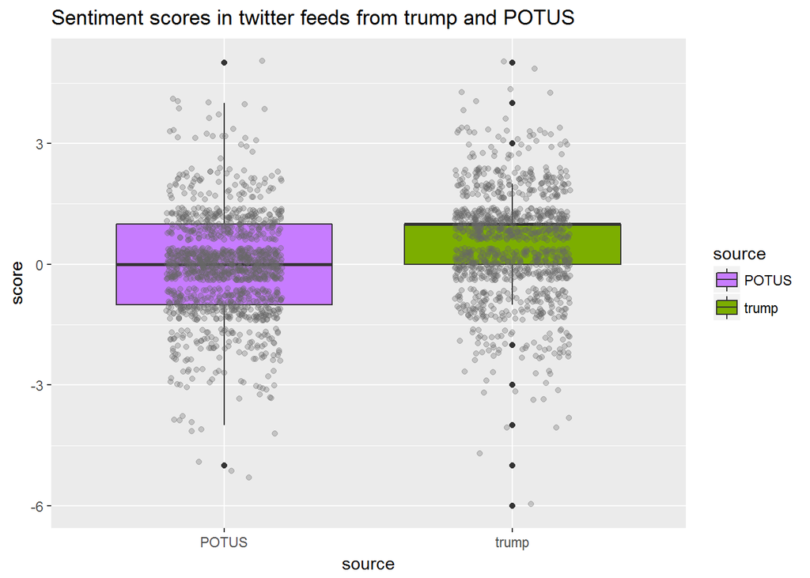

```r
cols <- c("#7CAE00","#C77CFF")
names(cols) <- c("trump", "POTUS")

# boxplot
ggplot(trump_POTUS_alltweets_score, aes(x=source, y=score, group=source)) +
  geom_boxplot(aes(fill=source)) +
  scale_fill_manual(values=cols) +
  geom_jitter(colour="gray40",
              position=position_jitter(width=0.2), alpha=0.3) +ggtitle(label ="Sentiment scores in twitter feeds from trump and POTUS")
```

10. Let’s check the barplots of average score :

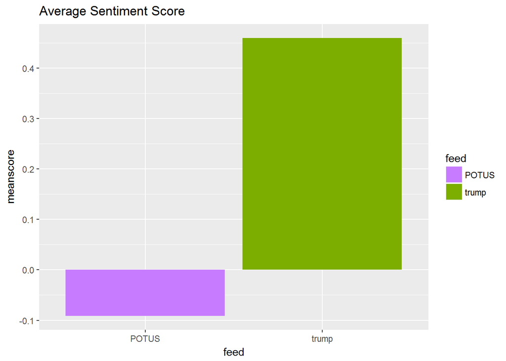

```r
trump_POTUS_alltweets_score_meanscores <- tapply(trump_POTUS_alltweets_score$score, trump_POTUS_alltweets_score$source, mean)
trump_POTUS_alltweets_score_meanscores_df <- data.frame(feed=names(trump_POTUS_alltweets_score_meanscores), meanscore=trump_POTUS_alltweets_score_meanscores)
trump_POTUS_alltweets_score_meanscores_df$feed<-reorder(trump_POTUS_alltweets_score_meanscores_df$feed,trump_POTUS_alltweets_score_meanscores_df$meanscore)

ggplot(trump_POTUS_alltweets_score_meanscores_df, aes(x=feed,y=meanscore)) +
  geom_bar(data=trump_POTUS_alltweets_score_meanscores_df, aes(x=feed, fill=feed),stat="identity") +
  scale_fill_manual(values=cols[order(trump_POTUS_alltweets_score_meanscores_df$meanscore)]) +
  ggtitle(label ="Average Sentiment Score")
```

```r
meanscores_compare<-trump_POTUS_alltweets_score%>%group_by(source)%>%summarise(meanscore=mean(score),mean_verypos=mean(very_positive),mean_pos=mean(positive),mean_neutral=mean(neutral),mean_neg=mean(negative),mean_veryneg=mean(very_negative))
meanscores_compare<-as.data.frame(meanscores_compare)
sumscores_compare<-trump_POTUS_alltweets_score%>%group_by(source)%>%summarise(sumscore=sum(score),sum_vp=sum(very_positive),sum_p=sum(positive),sum_n=sum(neutral),sum_neg=sum(negative),sum_vn=sum(very_negative))
sumscores_compare<-as.data.frame(sumscores_compare)
library(tidyr)
library(gridExtra)
```

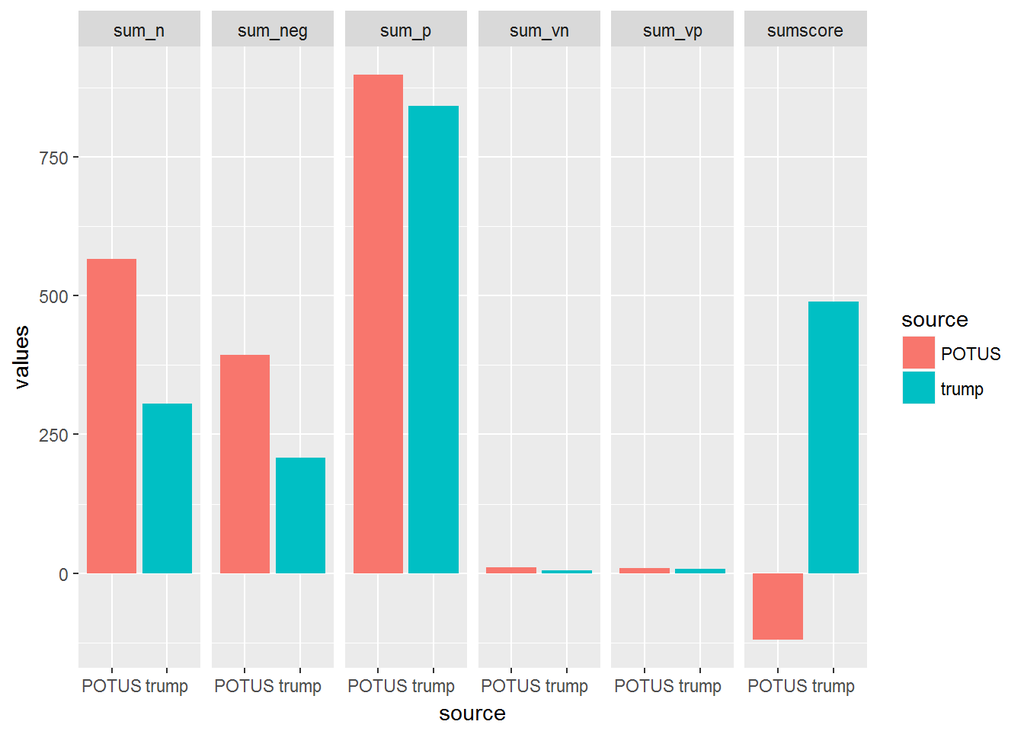

```r
sumscore_compare_long<-gather(data = sumscores_compare,key = key,value = values,-source)
ggplot(sumscore_compare_long,aes(x=source,y=values))+geom_histogram(stat="identity",aes(fill=source))+facet_grid(~key)
```

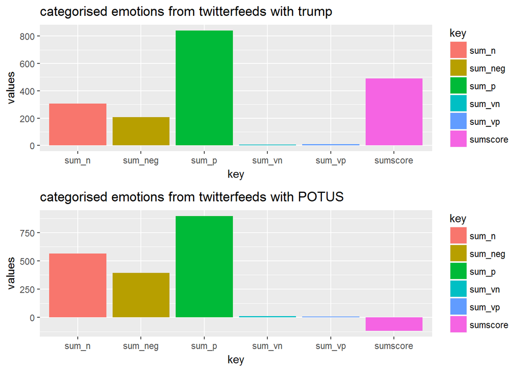

```r
p1<-sumscore_compare_long%>%filter(source=="trump")%>%ggplot(aes(x=key,y=values))+geom_histogram(stat="identity",aes(fill=key))+ggtitle(label = "categorised emotions from twitterfeeds with trump")
p2<-sumscore_compare_long%>%filter(source=="POTUS")%>%ggplot(aes(x=key,y=values))+geom_histogram(stat="identity",aes(fill=key))+ggtitle(label = "categorised emotions from twitterfeeds with POTUS")
grid.arrange(p1,p2,ncol=1,nrow=2)
```